# Project 1

Author

Yuan Xie

# 1 Dogs Data

## 1.1 Image of dogs

Search for an image of dogs and include it (i.e. insert it) in your document.

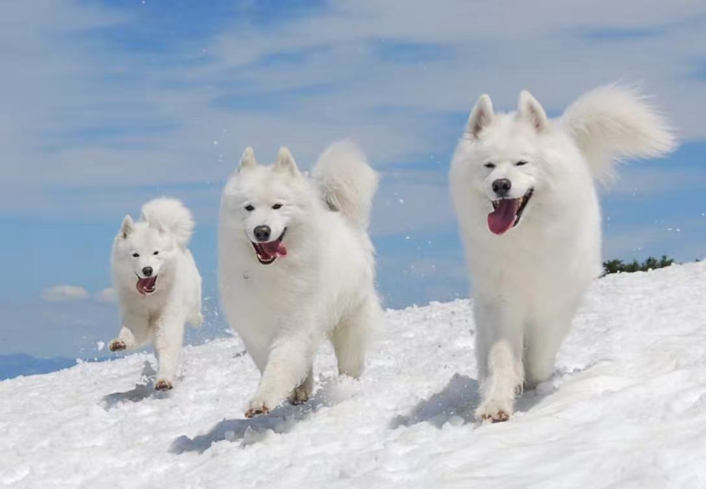

## 1.2 Vectors

Consider the following data about 10 dog breeds

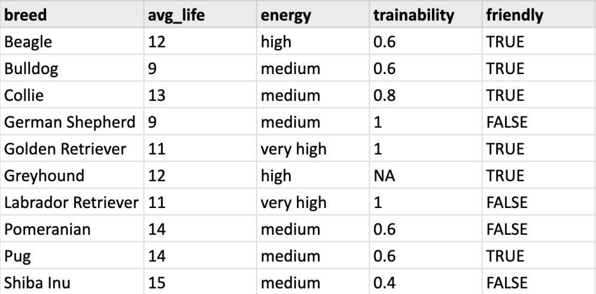

Create vectors and factors for the columns in the data table displayed above, according to the following data types. Encode missing values as `NA`. BTW: You **cannot** use any of the explicit coercion functions: e.g. `as.integer()`, `as.logical()`, etc.

- `breed`: character vector
- `avg_life`: integer vector (expectancy life in years)
- `energy`: factor (energy level); hint: `factor()` is your friend
- `trainability`: double or real vector (trainability level)
- `friendly`: logical vector (tends to be very friendly)

```r
# breed: character vector
breed <- c("Beagle", "Bulldog", "Collie", "German Shepherd",
           "Golden Retriever", "Greyhound", "Labrador Retriever",
           "Pomeranian", "Pug", "Shiba Inu")
breed
```

```
 [1] "Beagle"             "Bulldog"            "Collie"
 [4] "German Shepherd"    "Golden Retriever"   "Greyhound"
 [7] "Labrador Retriever" "Pomeranian"         "Pug"
[10] "Shiba Inu"
```

```r
# avg_life: integer vector
avg_life <- c(12L, 9L, 13L, 9L, 11L, 12L, 11L, 14L, 14L, 15L)
avg_life
```

```
 [1] 12  9 13  9 11 12 11 14 14 15
```

```r
# energy: factor
energy <- factor(c("high", "medium", "medium", "medium", "very high",
                   "high", "very high", "medium", "medium", "medium"))
energy
```

```
 [1] high      medium    medium    medium    very high high      very high
 [8] medium    medium    medium
Levels: high medium very high
```

```r
# trainability: double (real) vector
trainability <- c(0.6, 0.6, 0.8, 1.0, 1.0, NA, 1.0, 0.6, 0.6, 0.4)
trainability
```

```
 [1] 0.6 0.6 0.8 1.0 1.0  NA 1.0 0.6 0.6 0.4
```

```r
# friendly: logical vector
friendly <- c(TRUE, TRUE, TRUE, FALSE, TRUE, TRUE, FALSE, FALSE, TRUE, FALSE)
friendly
```

```
 [1]  TRUE  TRUE  TRUE FALSE  TRUE  TRUE FALSE FALSE  TRUE FALSE
```

## 1.3 Subscripting (aka Indexing, Slicing)

Use **bracket** notation to write R commands—displaying the output—that answer the following questions. Answer each part in its individual code chunk.  
a) What is the breed with the longest average life expectancy diameter? Hint: the function `which.max()` is your friend.

```r
breed[which.max(avg_life)]
```

```
[1] "Shiba Inu"
```

b) How many breeds don’t tend to be very friendly? Hint: the function `sum()` is your friend.

```r
sum(friendly == FALSE)
```

```
[1] 4
```

c) What is the median trainability value of those breeds that are friendly?

```r
median(trainability[friendly == TRUE], na.rm = TRUE)
```

```
[1] 0.6
```

d) How many breeds have average life expectancy values smaller than the median average life expectancy?

```r
sum(avg_life < median(avg_life))
```

```
[1] 4
```

e) How many breeds have medium energy level and tend to be very friendly?

```r
sum(energy == "medium" & friendly == TRUE)
```

```
[1] 3
```

f) What breeds have medium energy level and tend to be very friendly?

```r
breed[energy == "medium" & friendly == TRUE]
```

```
[1] "Bulldog" "Collie"  "Pug"
```

g) What is the minimum trainability value for those breeds with an average lifetime of 13 years or more? Hint: Pay attention to `NA` values.

```r
min(trainability[avg_life >= 13], na.rm = TRUE)
```

```
[1] 0.4
```

# 2 Vectorized Functions

For each function or operator listed below, state whether the function/operator is vectorized and provide a code example to support your claim.

1. `length()`: False. It just returns the length of a vector, which is a single value. It does not calculate each element one by one.

```r
x <- c(1, 2, 3, 4)
length(x)
```

```
[1] 4
```

2. `*`: True. It multiplies each element of a vector by another vector or a scalar.

```r
x <- c(1, 2, 3, 4)
x * 2
```

```
[1] 2 4 6 8
```

3. `log()`: True. It applies the logarithmic function to each element of the vector.

```r
x <- c(1, 2, 3, 4)
log(x)
```

```
[1] 0.0000000 0.6931472 1.0986123 1.3862944
```

4. `max()`: False. It changes the vector to the single largest value rather than operating element-wise.

```r
x <- c(1, 2, 3, 4)
max(x)
```

```
[1] 4
```

5. `trunc()`: True. This function actually rounds each number towards zero one by one.

```r
x <- c(1.1, 2.6, 3.2, 4.8)
trunc(x)
```

```
[1] 1 2 3 4
```

# 3 Loan Amortization Payment Formula

Consider the following formula for computing the periodic payment (PMT) of a loan amortization:、
$$\begin{equation}
\text{PMT} = P \times
\frac{\frac{r}{k}\left(1 + \frac{r}{k}\right)^{nk}}
{\left(1 + \frac{r}{k}\right)^{nk} - 1}
\end{equation}$$
where:
- P = principal (loan amount)
- PMT = periodic payment (typically monthly)
- $r$ = interest rate
- $n$ = number of years
- $k$ = number of periodic payments (typically 12: monthly)
**What it is**: when $k$ = 12, this formula gives you the monthly payment of a loan amortization.
**How to use it**: calculate the fixed periodic—usually monthly—payment of a loan.
**Best for**: Amortization is used in personal loan, home loan (mortgage), auto loan, student loan repayment schedule preparation.

## 3.1 Computing Payment

Write R code to answer the following question.  
Suppose that one of your friends recently graduated from a College in California with $45,000 in student loan debt, at an interest rate of 5.25%. What would be the monthly payment if your friend wants to pay-off their student loan in 20 years?

```r
# input the data
P <- 45000
r <- 0.0525
n <- 20
k <- 12

# plug these data into the function provided
PMT <- P * ( (r / k) * (1 + r / k)^(n * k) ) /
              ( (1 + r / k)^(n * k) - 1 )

PMT
```

```
[1] 303.2299
```

**Interpretation**: The monthly payment should be 303.2299 dollars.

## 3.2 Computing Years

Write R code to answer the following question.  
Your friend has various monthly payments to make such as rent, car loan, cell-phone, internet, streaming services, etc. With so many things to pay for, your friend is thinking of making monthly payments of $220 to pay for their student loan. How many years would it take your friend to be student-loan debt free if they plan to make monthly payments of $220? *Hint*: use a trial-and-error process for various values of $n$ to find the answer.

```r
# input the data
P <- 45000
r <- 0.0525
k <- 12
expected_PMT <- 220

n_vals <- seq(10, 60, by = 0.1)

# calculate all the corresponding PMT values
PMT_vals <- P * ( (r / k) * (1 + r / k)^(n_vals * k) ) /
                  ( (1 + r / k)^(n_vals * k) - 1 )
# find the number of year with the smallest difference
n_vals[which.min(abs(PMT_vals - expected_PMT))]
```

```
[1] 43
```

**Interpretation**: It will take 43 years.

# 4 Future Value of Ordinary Annuity

Mrs. Savingswood wants to save money for the college education of her 3 year-old daughter. She plans to deposit $100 at the end of each month, for the next 15 years, into a mutual fund that gives—on average—a 10% annual rate of return. How much money will Mrs. Savingswood have at the end of 15 years?
We can answer this question with the Future Value of an Ordinary Annuity formula:
$$\text{FV ordinary annuity} \;\longrightarrow\;
\text{FV} = \text{PMT} \times
\frac{\left(1 + \frac{r}{k}\right)^{nk} - 1}{r/k}$$
where:
- FV = future value (amount accumulated)
- PMT = periodic contribution made at the end of each period
- $r$ = annual interest rate (i.e. annual rate of return)
- $n$ = number of years
- $k$ = number of compounding periods per year; e.g. yearly ($k$ = 1), twice yearly ($k$ = 2), quarterly ($k$ = 4) and monthly ($k$ = 12).
Notice that if $r$ = 0 then:
$$\text{FV} = \text{PMT} \times nk$$

## 4.1 Function `annuity()`

- Based on the formula from equation 2, write a function `annuity()`, that allows you to compute the **future value of an ordinary annuity**.
- Make sure your function works with $r$ = 0
- Give descriptive names to the arguments of the function.
- Likewise, give default values to the arguments.
- Don’t forget to include comments to document the arguments of the function.

```r
# set the function with default parameters
annuity <- function(payment = 100,
                    annual_rate = 0.05,
                    years = 10,
                    periods_per_year = 12) {

  # total number of payments
  ## nk
  n_periods <- years * periods_per_year

  # handle the case where interest rate is zero
  if (annual_rate == 0) {
    ## FV = PMT * nk
    FV <- payment * n_periods
  } else {
    ## r/k
    rate_per_period <- annual_rate / periods_per_year
    ## plug into the whole formula
    FV <- payment * ((1 + rate_per_period)^n_periods - 1) / rate_per_period
  }

  return(FV)
}
```

## 4.2 Using `annuity()`

Use your function `annuity()` to find how much money Mrs. Savingswood will have at the end of 15 years.

```r
# just plugging the parameters into the defined function
annuity(payment = 100,
         annual_rate = 0.10,
         years = 15,
         periods_per_year = 12)
```

```
[1] 41447.03
```

**Interpretation**: Mrs. Savingswood will have 41447.03 dollars.